# Modelos Lineares Generalizados

Modelo linear generalizado com resposta binomial e função de ligação logito

Deivison Venicio Souza

05/setembro/2018

```r
library(rmarkdown)
knitr::opts_chunk$set(fig.align="center", cache=F, prompt=FALSE, comment = NA, eval = TRUE)
```

# 1 Descrição da atividade

Vamos considerar a aplicação de um modelo linear generalizado com resposta binomial e função de ligação logito (regressão logística). Os dados são referentes a 699 nódulos de mama. O objetivo é ajustar um modelo preditivo, que permita classificá-los em benignos ou malignos com base num conjunto de covariáveis. Segue a descrição das variáveis usadas na análise:

- CL: Clump Thickness;
- MA: Marginal Adhesion;
- BC: Bland Chromatin;
- Class: benign, para benigno; malignant, para maligno (variável resposta).

As três primeiras variáveis (variáveis explicativas) são expressas numa escala numérica, com valores 0, 1, 2,. . . , 10. Além disso, a variável resposta foi codificada, para a análise, de forma que y = 0, se o tumor é benigno, e y = 1, caso o tumor seja maligno. Assim, vamos modelar a probabilidade (ou melhor, a chance) de um tumor ser maligno.

O conjunto de dados **BreastCancer** utilizado está disponível no pacote **mlbench** e, constitui informações sobre câncer de mama de Wisconsin (Wisconsin Breast Cancer). O objetivo é identificar cada uma das classes benignas ou malignas. O conjunto de dados possui 699 observações e 11 variáveis, sendo uma delas a classe alvo. Para este estudo utilizar-se-á apenas das variáveis **Cl.thickness** (Clump Thickness), **Marg.adhesion** (Marginal Adhesion), **Bl.cromatin** (Bland Chromatin) e **Class** (variável resposta). Para facilitar as variáveis explicativas foram renomeadas para **CT**, **MA** e **BC**.

Um modelo linear generalizado é definido pela especificação de três componentes: (**Fonte**: slides de aula)

**1) O componente aleatório**;

A especificação do componente aleatório do modelo GLM requer:

- Requer a definição de uma distribuição de probabilidades para a variável resposta.
- A variável resposta é discreta ou contínua? Sua distribuição é simétrica? Qual o conjunto de valores com probabilidade não nula?
- Deve-se propor um modelo que tenha propriedades compatíveis à distribuição dos dados;
- Não se tendo convicção sobre uma particular escolha, pode-se testar diferentes alternativas ou usar alguma abordagem que não exija essa especificação.

**2) O componente sistemático**; e

- Preditor linear do modelo, em que são inseridas as covariáveis por meio de uma combinação linear de parâmetros.

**3) Uma função de ligação**.

- Função real, monótona e diferenciável, denotada por `g()`, que conecta os componentes aleatório e sistemático do modelo.
- A função de ligação tem o papel de linearizar a relação entre os componentes aleatório e sistemático do modelo.
- Proporcionar interpretações práticas para os parâmetros de regressão (betas).

| **Para o estudo de caso em questão a especificação dos componentes do GLM ficaria:** |
| --- |

- **Componente aleatório**: `Resposta Y possui distribuição binomial (benign, malignant)`
- **Componente sistemático**: $n_{i} = \beta_{0} + \beta_{1}CT_{i} + \beta_{2}MA_{i} + \beta_{3}BC_{i}$
- **Função de ligação**: `g() = logito`

# 2 Carregando pacote

```r
library(mlbench)                            # contém o conjunto de dados "BreastCancer"
library(dplyr)                              # função mutate_if()
library(magrittr)                           # piper
library(statmod)                            # resíduos quantílicos (função qres.binom())
library(hnp)                                # gráficos meio-normais
library(caret)                              # sensibilidade
library(effects)                            # grafico de efeitos
```

# 3 Carregando dados e fazendo manipulações

Para ajustar o modelo usando a função `glm` foi necessário realizar a conversão das variáveis “CT”, “MA” e “BC” para classe `numeric`. Originalmente estas varáveis aparecem com classe **factor** ocasionando erro no ajuste do modelo.

```r
data(BreastCancer)                                # carrega conjunto de dados
breast <- BreastCancer[,c(2,5,8,11)]              # seleciona variáveis de interesse
colnames(breast) <- c("CT", "MA", "BC", "Class")  # renomeia as variáveis
str(breast)                                       # estrutura do data frame
'data.frame':   699 obs. of  4 variables:
 $ CT   : Ord.factor w/ 10 levels "1"<"2"<"3"<"4"<..: 5 5 3 6 4 8 1 2 2 4 ...
 $ MA   : Ord.factor w/ 10 levels "1"<"2"<"3"<"4"<..: 1 5 1 1 3 8 1 1 1 1 ...
 $ BC   : Factor w/ 10 levels "1","2","3","4",..: 3 3 3 3 3 9 3 3 1 2 ...
 $ Class: Factor w/ 2 levels "benign","malignant": 1 1 1 1 1 2 1 1 1 1 ...

breast[,1:3] %<>% mutate_if(is.factor,as.numeric) # transforma de factor p/ numeric
str(breast)                                       # estrutura do data frame
'data.frame':   699 obs. of  4 variables:
 $ CT   : num  5 5 3 6 4 8 1 2 2 4 ...
 $ MA   : num  1 5 1 1 3 8 1 1 1 1 ...
 $ BC   : num  3 3 3 3 3 9 3 3 1 2 ...
 $ Class: Factor w/ 2 levels "benign","malignant": 1 1 1 1 1 2 1 1 1 1 ...

head(breast, 10)                                  # ler as primeiras 6 linhas
```

|  | CT | MA | BC | Class |
| --- | --- | --- | --- | --- |
| 1 | 5 | 1 | 3 | benign |
| 2 | 5 | 5 | 3 | benign |
| 3 | 3 | 1 | 3 | benign |
| 4 | 6 | 1 | 3 | benign |
| 5 | 4 | 3 | 3 | benign |
| 6 | 8 | 8 | 9 | malignant |
| 7 | 1 | 1 | 3 | benign |
| 8 | 2 | 1 | 3 | benign |
| 9 | 2 | 1 | 1 | benign |
| 10 | 4 | 1 | 2 | benign |

# 4 Análise exploratória dos dados

## 4.1 Distribuição das variáveis

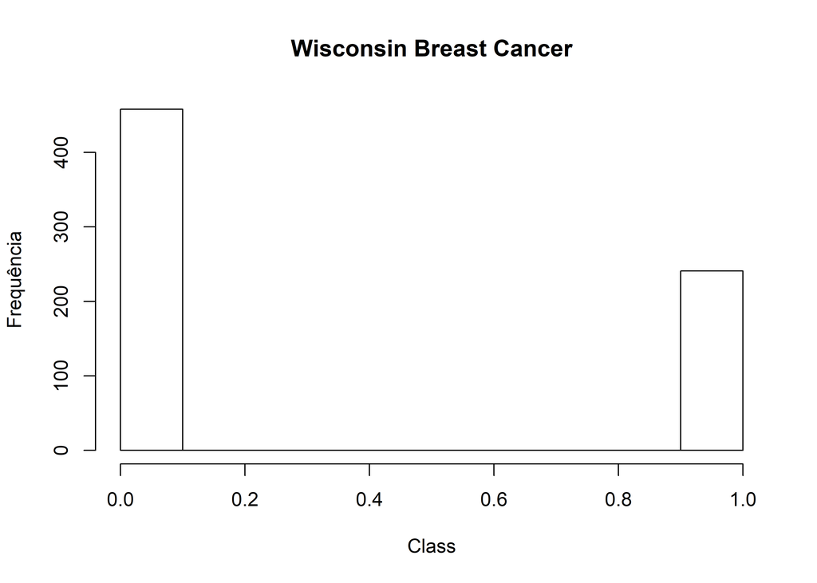

```r
# Histograma: constata-se que a variável resposta (Class) tem distribuição binomial

with(breast, hist(ifelse(Class == 'malignant',1 ,0), main = 'Wisconsin Breast Cancer',
                  xlab = 'Class', ylab = 'Frequência'))
```

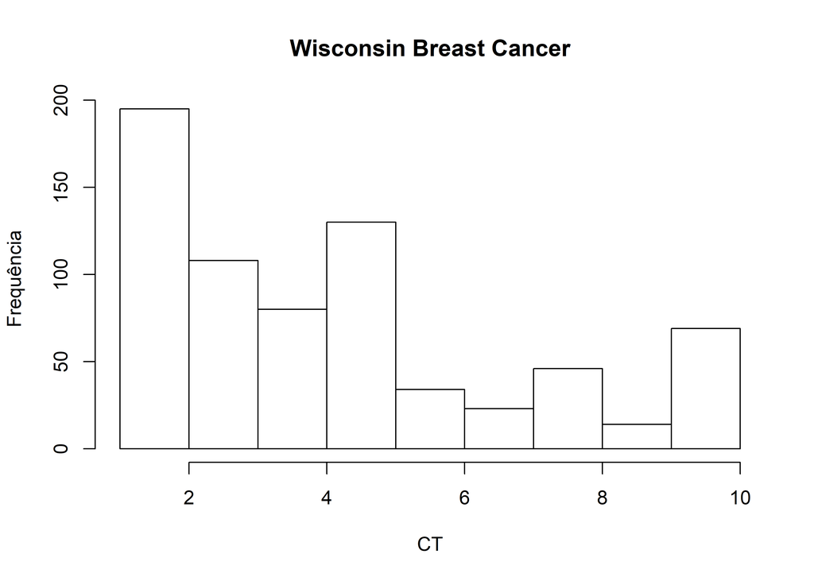

```r
# Histograma de frequência p/ variável CT
with(breast, hist(CT, main = 'Wisconsin Breast Cancer', xlab = 'CT', ylab = 'Frequência'))
```

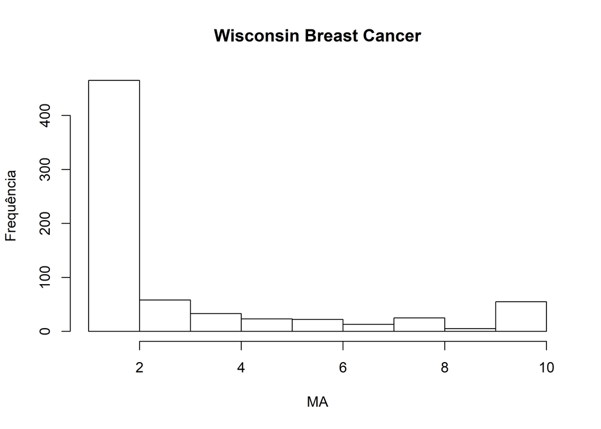

```r
# Histograma de frequência p/ variável MA
with(breast, hist(MA, main = 'Wisconsin Breast Cancer', xlab = 'MA', ylab = 'Frequência'))
```

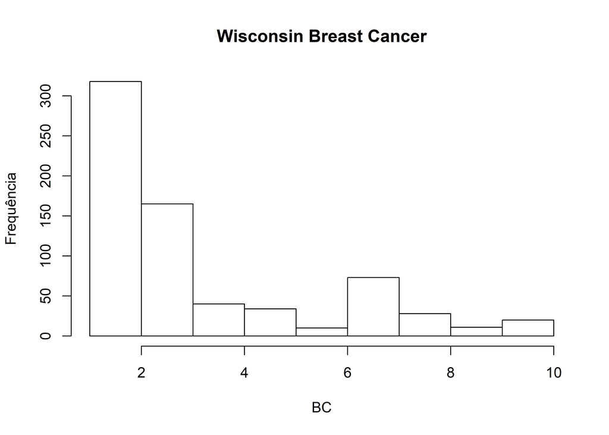

```r
# Histograma de frequência p/ variável BC
with(breast, hist(BC, main = 'Wisconsin Breast Cancer', xlab = 'BC', ylab = 'Frequência'))
```

## 4.2 Tabelas de frequências

```r
with(breast,table(Class))                 # tabela freq. p/ variável Class
Class
   benign malignant
      458       241

with(breast,prop.table(table(Class))*100) # tabela freq. p/ variável Class (%)
Class
   benign malignant
 65.52217  34.47783

with(breast, table(Class, CT))            # tabela freq. p/ variável CT
           CT
Class         1   2   3   4   5   6   7   8   9  10
  benign    142  46  96  68  85  16   1   4   0   0
  malignant   3   4  12  12  45  18  22  42  14  69

with(breast, table(Class, MA))            # tabela freq. p/ variável MA
           MA
Class         1   2   3   4   5   6   7   8   9  10
  benign    375  37  31   5   4   4   0   0   1   1
  malignant  32  21  27  28  19  18  13  25   4  54

with(breast, table(Class, BC))            # tabela freq. p/ variável BC
           BC
Class         1   2   3   4   5   6   7   8   9  10
  benign    150 159 129   8   4   1   7   0   0   0
  malignant   2   7  36  32  30   9  66  28  11  20
```

# 5 Dividindo conjunto de dados: Treino e Teste

Para avaliar a capacidade preditiva do modelo a ser ajustado, a base foi dividida, aleatoriamente, em duas novas bases: a primeira, com 500 observações, para o ajuste; a segunda, com 199 linhas, para validação. Na sequência é apresentado o resumo do modelo ajustado.

```r
set.seed(232)                                      # semente de reprodutibilidade.
ordem <- sample(1:nrow(breast))                    # sorteio aleatório de linhas.
breast_aj <- breast[ordem[1:500],]                 # cria base de ajuste.
breast_pred <- breast[ordem[501:nrow(breast)],]    # cria base de validação.

summary(breast_aj)                                 # sumário dos dados de treino
       CT               MA               BC               Class
 Min.   : 1.000   Min.   : 1.000   Min.   : 1.000   benign   :333
 1st Qu.: 2.000   1st Qu.: 1.000   1st Qu.: 2.000   malignant:167
 Median : 4.000   Median : 1.000   Median : 3.000
 Mean   : 4.438   Mean   : 2.752   Mean   : 3.452
 3rd Qu.: 6.000   3rd Qu.: 3.000   3rd Qu.: 5.000
 Max.   :10.000   Max.   :10.000   Max.   :10.000

summary(breast_pred)                               # sumário dos dados de teste
       CT               MA               BC               Class
 Min.   : 1.000   Min.   : 1.000   Min.   : 1.000   benign   :125
 1st Qu.: 2.000   1st Qu.: 1.000   1st Qu.: 2.000   malignant: 74
 Median : 4.000   Median : 1.000   Median : 3.000
 Mean   : 4.367   Mean   : 2.945   Mean   : 3.402
 3rd Qu.: 5.000   3rd Qu.: 4.000   3rd Qu.: 4.500
 Max.   :10.000   Max.   :10.000   Max.   :10.000
```

# 6 Ajuste do modelo - Família binomial e função de ligação logito

Utilizou-se a função `glm` do pacote **stats** para ajustar o modelo linear generalizado. No argumento `family` especificou-se a família binomial (enquanto distribuição da variável resposta Y). Sabendo que a probabilidade do nódulo ser **benign** e **malignant** varia de 0 a 1, é necessário usar uma função de ligação que limite a resposta de Y a esse intervalo. A função de ligação escolhida para isso foi a `logit` (logito).

O modelo foi ajustado usando as covariáveis **CT**, **MA** e **BC**. Aplicando-se a função **summary** pode obter um resumo do ajuste, com os betas estimados, o erro padrão associado a cada parâmetro estimado, AIC, e teste de Wald. Além disso, pode-se observar quais covariáveis apresentam efeito significativo na classificação do tumor. A partir da análise da significância dos parâmetros estimados (betas) constata-se que todas as covariáveis foram altamente significativas (***), isto é, estão altamente associadas a uma maior probabilidade de ocorrência de tumor maligno.

```r
ajuste <- glm(formula = Class ~ CT + MA + BC, family = binomial(link = 'logit'), data =
                breast_aj)        # ajuste da regressão logística

names(ajuste)                     # elementos disponíveis no objeto ajuste
 [1] "coefficients"      "residuals"         "fitted.values"
 [4] "effects"           "R"                 "rank"
 [7] "qr"                "family"            "linear.predictors"
[10] "deviance"          "aic"               "null.deviance"
[13] "iter"              "weights"           "prior.weights"
[16] "df.residual"       "df.null"           "y"
[19] "converged"         "boundary"          "model"
[22] "call"              "formula"           "terms"
[25] "data"              "offset"            "control"
[28] "method"            "contrasts"         "xlevels"

summary(ajuste)                   # sumário do ajuste

Call:
glm(formula = Class ~ CT + MA + BC, family = binomial(link = "logit"),
    data = breast_aj)

Deviance Residuals:
    Min       1Q   Median       3Q      Max
-3.5333  -0.1925  -0.0702   0.0367   2.4677

Coefficients:
            Estimate Std. Error z value Pr(>|z|)
(Intercept)  -9.9033     1.0396  -9.526  < 2e-16 ***
CT            0.9118     0.1268   7.193 6.34e-13 ***
MA            0.4917     0.1078   4.562 5.07e-06 ***
BC            0.8925     0.1460   6.113 9.75e-10 ***
---
Signif. codes:  0 '***' 0.001 '**' 0.01 '*' 0.05 '.' 0.1 ' ' 1

(Dispersion parameter for binomial family taken to be 1)

    Null deviance: 636.98  on 499  degrees of freedom
Residual deviance: 129.33  on 496  degrees of freedom
AIC: 137.33

Number of Fisher Scoring iterations: 7
```

# 7 Modelo ajustado e estimação pontual

- **Na escala do preditor**:

$$ln \left[\frac{\pi_{x}}{1-\pi_{x}}\right] = \beta_{0} + \beta_{1}CT_{i} + \beta_{2}MA_{i} + \beta_{3}BC_{i}$$

$$ln \left[\frac{\pi_{x}}{1-\pi_{x}}\right] = -9.9033 + 0.9118CT_{i} + 0.4917MA_{i} + 0.8925BC_{i}$$

- **Na escala da resposta Y**:

$$\frac{\pi_{x}}{1-\pi_{x}} = e^{\beta_{0} + \beta_{1}CT_{i} + \beta_{2}MA_{i} + \beta_{3}BC_{i}}$$

$$\pi_{x} = \frac{e^{\beta_{0} + \beta_{1}CT_{i} + \beta_{2}MA_{i} + \beta_{3}BC_{i}}}{e^{\beta_{0} + \beta_{1}CT_{i} + \beta_{2}MA_{i} + \beta_{3}BC_{i}}+ 1}$$

$$\pi_{x} = \frac{e^{-9.9033 + 0.9118CT_{i} + 0.4917MA_{i} + 0.8925BC_{i}}}{e^{-9.9033 + 0.9118CT_{i} + 0.4917MA_{i} + 0.8925BC_{i}}+ 1}$$

**Com base na questão 2**: Para nódulos com CT=4, MA=4 e BC=5, a probabilidade estimada do tumor ser maligno é:

**O cálculo manual na escala do preditor fica**:

Y = -9.9033+0.9118*4+0.4917*4+0.8925*5

```r
(Y <- ajuste$coefficients[1]+ajuste$coefficients[2]*4+
               ajuste$coefficients[3]*4+ajuste$coefficients[4]*5)
(Intercept)
  0.1732684
```

**O cálculo manual na escala da resposta Y fica**:

Y = exp(-9.9033+0.9118*4+0.4917*4+0.8925*5)/(exp(-9.9033+0.9118*4+0.4917*4+0.8925*5)+1)

```r
(Y <- exp(ajuste$coefficients[1]+ajuste$coefficients[2]*4+
               ajuste$coefficients[3]*4+ajuste$coefficients[4]*5)/
   (exp(ajuste$coefficients[1]+ajuste$coefficients[2]*4+
          ajuste$coefficients[3]*4+ajuste$coefficients[4]*5)+1))
(Intercept)
  0.5432091
```

**Agora, usando a função predict do R**:

- **Na escala do preditor**:

```r
new_data <- data.frame(CT=4, MA=4, BC=5)

# Predição na escala do preditor (link).
predict(ajuste, newdata = new_data)
        1
0.1732684

# Predição na escala do preditor (link), com os erros padrões associados.
p_link <- predict(ajuste, newdata = new_data, se.fit = TRUE)

# IC (95%) na escala do preditor (link), para a nova observação.
(IC_link <- cbind(LI = p_link$fit - 1.96 * p_link$se.fit,
                  LS = p_link$fit + 1.96 * p_link$se.fit))
          LI        LS
1 -0.4717208 0.8182577
```

- **Na escala da resposta Y**:

```r
# Predição na escala de probabilidade da resposta (inversa do link).
predict(ajuste, newdata = new_data, type = 'response')
        1
0.5432091

# Predição na escala de probabilidade da resposta, com os erros padrões associados.
p_resp <- predict(ajuste, newdata = new_data, type = 'response', se.fit = TRUE)

# IC (95%) na escala de probabilidade da resposta, para a nova observação.
(IC_resp <- cbind(LI = p_resp$fit - 1.96 * p_resp$se.fit,
                  LS = p_resp$fit + 1.96 * p_resp$se.fit))
        LI        LS
1 0.383166 0.7032522

#exp(IC_link)/(exp(IC_link) + 1)
```

# 8 Predições - Conjunto de treino

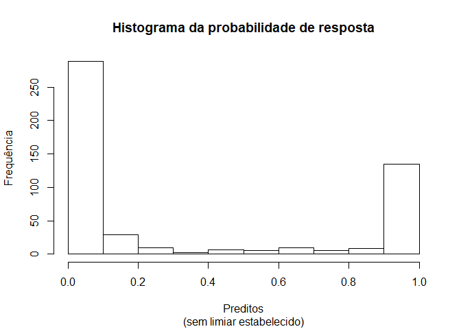

```r
# Predição na escala do preditor (link)
breast_aj$pred_pred <- predict(ajuste, newdata = breast_aj)

# Predição na escala da resposta (probabilidade, inversa do link)
breast_aj$pred_resp <- predict(ajuste, newdata = breast_aj, type = 'response')

hist(breast_aj$pred_resp, xlab = "Preditos", ylab = "Frequência",
     main = "Histograma da probabilidade de resposta",
     sub = "(sem limiar estabelecido)")
```

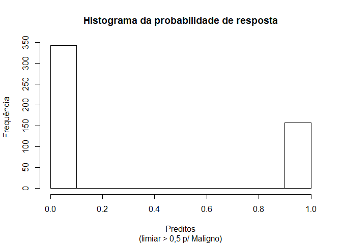

```r
# Matriz de confusão - conjunto de treino
breast_aj$pred2 <- ifelse(breast_aj$pred_pred > 0.5, 1, 0)

hist(breast_aj$pred2, xlab = "Preditos", ylab = "Frequência",
     main = "Histograma da probabilidade de resposta",
     sub = "(limiar > 0,5 p/ Maligno)")
```

```r
tab1 <- table(Predito = breast_aj$pred2, Observado = breast_aj$Class)
dimnames(tab1)[[1]] <- c('benign', 'malignant')
print(tab1)
           Observado
Predito     benign malignant
  benign       325        17
  malignant      8       150
```